# Worked Example: Cars

The same data tasks in R and Python

Authors

Johan Larsson

Behnaz Pirzamanbein

Jonas Wallin

In this example, we will import a table of used cars, wrangle it, and summarize it. Each step has matching **R** and **Python** examples. Choose a language in any tab to switch all the tabs, and run the examples in order so that earlier objects are available.

We use the same data files in both languages. Keep the `data` folder beside this file. See R and Python: a practical guide for more comparisons of syntax and defaults.

## Getting started

Install packages once, then load or import them in each new session. In R, we use the **tidyverse** collection of packages. In Python, we use **NumPy**, **pandas**, and **seaborn/matplotlib**.

**R**

If needed, run this once to install tidyverse:

```r
install.packages("tidyverse")
```

```r
library(tidyverse)
```

**Python**

If needed, run this once in a terminal:

```bash
python -m pip install numpy pandas matplotlib seaborn
```

```python
from pathlib import Path
import numpy as np
import pandas as pd
import matplotlib.pyplot as plt
import seaborn as sns

DATA_DIR = Path("data")
sns.set_theme(style="whitegrid", context="notebook")
```

**Rendering the Quarto source**

You can read the HTML page and copy examples without rendering it yourself. To render `cars.qmd`, install Quarto, the R packages `tidyverse`, `knitr`, `rmarkdown`, and `reticulate`, and the Python packages listed above. Both languages run when the document is rendered.

Quarto uses [knitr and reticulate to run R and Python together](https://quarto.org/docs/computations/execution-options.html#engine-binding). Make sure reticulate uses the Python environment where you installed the packages; see [Python version configuration](https://rstudio.github.io/reticulate/articles/versions.html).

Open `cars.qmd` in RStudio and click **Render**, or run this command from the folder containing the file:

```bash
quarto render cars.qmd
```

## Importing data

We use `read_csv()` in R and `pd.read_csv()` in Python to read a comma-separated file. A copy of the US Cars dataset is included in `data`, so there is no need to download it each time. Paths are relative to the folder containing this file.

**R**

```r
us_cars <- read_csv(file.path("data", "us_cars.csv"))
head(us_cars)
```

```
# A tibble: 6 × 12
  price brand  model  year title_status mileage color vin      lot state country
  <dbl> <chr>  <chr> <dbl> <chr>          <dbl> <chr> <chr>  <dbl> <chr> <chr>
1  6300 toyota crui…  2008 clean vehic…  274117 black jtez… 1.59e8 new … usa
2  2899 ford   se     2011 clean vehic…  190552 silv… 2fmd… 1.67e8 tenn… usa
3  5350 dodge  mpv    2018 clean vehic…   39590 silv… 3c4p… 1.68e8 geor… usa
4 25000 ford   door   2014 clean vehic…   64146 blue  1ftf… 1.68e8 virg… usa
5 27700 chevr… 1500   2018 clean vehic…    6654 red   3gcp… 1.68e8 flor… usa
6  5700 dodge  mpv    2018 clean vehic…   45561 white 2c4r… 1.68e8 texas usa
# ℹ 1 more variable: condition <chr>
```

**Python**

```python
us_cars = pd.read_csv(DATA_DIR / "us_cars.csv")
us_cars.head()
```

```
   price      brand    model  ...       state country      condition
0   6300     toyota  cruiser  ...  new jersey     usa   10 days left
1   2899       ford       se  ...   tennessee     usa    6 days left
2   5350      dodge      mpv  ...     georgia     usa    2 days left
3  25000       ford     door  ...    virginia     usa  22 hours left
4  27700  chevrolet     1500  ...     florida     usa  22 hours left

[5 rows x 12 columns]
```

Both functions can also read directly from a URL. You would replace the file path with `"https://raw.githubusercontent.com/stat-lu/dataviz/main/data/us_cars.csv"`. Use the bundled file for this exercise.

### Taking a glimpse

Whenever you start working with new data, take a look at the rows, column types, and missing values. Does everything look as you expect?

**R**

`glimpse()` shows each column and its type. `dim()` reports the number of rows and columns.

```r
glimpse(us_cars)
```

```
Rows: 2,499
Columns: 12
$ price        <dbl> 6300, 2899, 5350, 25000, 27700, 5700, 7300, 13350, 14600,…
$ brand        <chr> "toyota", "ford", "dodge", "ford", "chevrolet", "dodge", …
$ model        <chr> "cruiser", "se", "mpv", "door", "1500", "mpv", "pk", "doo…
$ year         <dbl> 2008, 2011, 2018, 2014, 2018, 2018, 2010, 2017, 2018, 201…
$ title_status <chr> "clean vehicle", "clean vehicle", "clean vehicle", "clean…
$ mileage      <dbl> 274117, 190552, 39590, 64146, 6654, 45561, 149050, 23525,…
$ color        <chr> "black", "silver", "silver", "blue", "red", "white", "bla…
$ vin          <chr> "jtezu11f88k007763", "2fmdk3gc4bbb02217", "3c4pdcgg5jt346…
$ lot          <dbl> 159348797, 166951262, 167655728, 167753855, 167763266, 16…
$ state        <chr> "new jersey", "tennessee", "georgia", "virginia", "florid…
$ country      <chr> "usa", "usa", "usa", "usa", "usa", "usa", "usa", "usa", "…
$ condition    <chr> "10 days left", "6 days left", "2 days left", "22 hours l…
```

```r
dim(us_cars)
```

```
[1] 2499   12
```

```r
summary(us_cars)
```

```
     price             brand            model           year
 Min.   :    0   Length   :2499   Length   :2499   Min.   :1973
 1st Qu.:10200   N.unique :  28   N.unique : 127   1st Qu.:2016
 Median :16900   N.blank  :   0   N.blank  :   0   Median :2018
 Mean   :18768   Min.nchar:   3   Min.nchar:   1   Mean   :2017
 3rd Qu.:25556   Max.nchar:  15   Max.nchar:  11   3rd Qu.:2019
 Max.   :84900                                     Max.   :2020
    title_status     mileage              color             vin
 Length   :2499   Min.   :      0   Length   :2499   Length   :2499
 N.unique :   2   1st Qu.:  21466   N.unique :  49   N.unique :2495
 N.blank  :   0   Median :  35365   N.blank  :   0   N.blank  :   0
 Min.nchar:  13   Mean   :  52299   Min.nchar:   3   Min.nchar:  13
 Max.nchar:  17   3rd Qu.:  63472   Max.nchar:  39   Max.nchar:  17
                  Max.   :1017936
      lot                  state           country         condition
 Min.   :159348797   Length   :2499   Length   :2499   Length   :2499
 1st Qu.:167625331   N.unique :  44   N.unique :   2   N.unique :  47
 Median :167745058   N.blank  :   0   N.blank  :   0   N.blank  :   0
 Mean   :167691389   Min.nchar:   4   Min.nchar:   3   Min.nchar:   9
 3rd Qu.:167779772   Max.nchar:  14   Max.nchar:   6   Max.nchar:  15
 Max.   :167805500
```

**Python**

`.info()` reports column types and nonmissing counts. `.shape` gives the number of rows and columns; `.describe()` summarizes the numeric columns by default.

```python
us_cars.info()
```

```
<class 'pandas.DataFrame'>
RangeIndex: 2499 entries, 0 to 2498
Data columns (total 12 columns):
 #   Column        Non-Null Count  Dtype
---  ------        --------------  -----
 0   price         2499 non-null   int64
 1   brand         2499 non-null   str
 2   model         2499 non-null   str
 3   year          2499 non-null   int64
 4   title_status  2499 non-null   str
 5   mileage       2499 non-null   int64
 6   color         2499 non-null   str
 7   vin           2499 non-null   str
 8   lot           2499 non-null   int64
 9   state         2499 non-null   str
 10  country       2499 non-null   str
 11  condition     2499 non-null   str
dtypes: int64(4), str(8)
memory usage: 234.4 KB
```

```python
print("Rows and columns:", us_cars.shape)
```

```
Rows and columns: (2499, 12)
```

```python
us_cars.describe()
```

```
              price         year       mileage           lot
count   2499.000000  2499.000000  2.499000e+03  2.499000e+03
mean   18767.671469  2016.714286  5.229869e+04  1.676914e+08
std    12116.094936     3.442656  5.970552e+04  2.038772e+05
min        0.000000  1973.000000  0.000000e+00  1.593488e+08
25%    10200.000000  2016.000000  2.146650e+04  1.676253e+08
50%    16900.000000  2018.000000  3.536500e+04  1.677451e+08
75%    25555.500000  2019.000000  6.347250e+04  1.677798e+08
max    84900.000000  2020.000000  1.017936e+06  1.678055e+08
```

## Wrangling

*Filtering* means selecting rows; *selecting* means choosing columns. The operations below return transformed tables. They do not change `us_cars` unless we assign the result back to it.

### Logical comparisons

Let’s first practice elementwise comparisons. In R we use vectors; in Python we use NumPy arrays for these vector operations.

**R**

```r
c(1, 2, 3) < c(0.2, 0.5, 3.8)
```

```
[1] FALSE FALSE  TRUE
```

```r
1:3 == 3:1
```

```
[1] FALSE  TRUE FALSE
```

```r
c("a", "b", "c") %in% c("a", "c")
```

```
[1]  TRUE FALSE  TRUE
```

**Python**

```python
print(np.array([1, 2, 3]) < np.array([0.2, 0.5, 3.8]))
```

```
[False False  True]
```

```python
print(np.arange(1, 4) == np.arange(3, 0, -1))
```

```
[False  True False]
```

```python
print(np.isin(["a", "b", "c"], ["a", "c"]))
```

```
[ True False  True]
```

### Filtering

Let’s say that we only want cars from Tennessee from 2015 onwards.

**R**

`filter()` takes the table first, followed by the conditions. Conditions separated by commas must all hold.

```r
filter(us_cars, state == "tennessee", year >= 2015)
```

```
# A tibble: 17 × 12
   price brand model  year title_status mileage color vin      lot state country
   <dbl> <chr> <chr> <dbl> <chr>          <dbl> <chr> <chr>  <dbl> <chr> <chr>
 1 31900 chev… 1500   2018 clean vehic…   22909 black 3gcu… 1.68e8 tenn… usa
 2 16500 buick enco…  2018 clean vehic…   20002 red   kl4c… 1.68e8 tenn… usa
 3 19200 chev… 1500   2018 clean vehic…    2430 white 1gcn… 1.68e8 tenn… usa
 4 30500 chev… 1500   2018 clean vehic…   30442 red   3gcu… 1.68e8 tenn… usa
 5 19000 chev… mali…  2017 clean vehic…   18414 white 1g1z… 1.68e8 tenn… usa
 6 27000 buick encl…  2017 clean vehic…   32107 no_c… 5gak… 1.68e8 tenn… usa
 7 29400 bmw   x3     2017 clean vehic…   23765 black 5uxw… 1.68e8 tenn… usa
 8  8500 ford  fusi…  2017 clean vehic…   78739 black 3fa6… 1.68e8 tenn… usa
 9 30300 ford  f-150  2019 clean vehic…   31899 white 1fte… 1.68e8 tenn… usa
10 39200 ford  max    2019 clean vehic…   43617 black 1fmj… 1.68e8 tenn… usa
11 41200 ford  srw    2019 clean vehic…   25638 gray  1ft7… 1.68e8 tenn… usa
12 29000 ford  door   2017 clean vehic…   42291 black 1fte… 1.68e8 tenn… usa
13 14500 niss… rogue  2017 clean vehic…    8677 blue  knma… 1.68e8 tenn… usa
14 18200 niss… sport  2018 clean vehic…   28009 black jn1b… 1.68e8 tenn… usa
15 10900 niss… sent…  2018 clean vehic…   28880 silv… 3n1a… 1.68e8 tenn… usa
16 12600 niss… sent…  2017 clean vehic…   11837 gray  3n1a… 1.68e8 tenn… usa
17 12700 niss… door   2017 clean vehic…   17738 black 1n4a… 1.68e8 tenn… usa
# ℹ 1 more variable: condition <chr>
```

**Python**

Use `.loc` to select rows satisfying a condition. Both comparisons need parentheses when combined with `&`.

```python
keep = (us_cars["state"] == "tennessee") & (us_cars["year"] >= 2015)
us_cars.loc[keep]
```

```
      price      brand    model  ...      state country      condition
12    31900  chevrolet     1500  ...  tennessee     usa  22 hours left
17    16500      buick   encore  ...  tennessee     usa  22 hours left
37    19200  chevrolet     1500  ...  tennessee     usa  22 hours left
42    30500  chevrolet     1500  ...  tennessee     usa  22 hours left
47    19000  chevrolet   malibu  ...  tennessee     usa  22 hours left
52    27000      buick  enclave  ...  tennessee     usa  22 hours left
72    29400        bmw       x3  ...  tennessee     usa  22 hours left
1206   8500       ford   fusion  ...  tennessee     usa    2 days left
1311  30300       ford    f-150  ...  tennessee     usa  21 hours left
1734  39200       ford      max  ...  tennessee     usa  21 hours left
1778  41200       ford      srw  ...  tennessee     usa  21 hours left
1860  29000       ford     door  ...  tennessee     usa  21 hours left
2320  14500     nissan    rogue  ...  tennessee     usa    4 days left
2332  18200     nissan    sport  ...  tennessee     usa  21 hours left
2337  10900     nissan   sentra  ...  tennessee     usa  21 hours left
2379  12600     nissan   sentra  ...  tennessee     usa  21 hours left
2381  12700     nissan     door  ...  tennessee     usa  21 hours left

[17 rows x 12 columns]
```

### Selecting

Select columns by name. Notice that pandas requires quoted column names, while dplyr usually lets you write names without quotes.

**R**

```r
select(us_cars, brand, model)
```

```
# A tibble: 2,499 × 2
   brand     model
   <chr>     <chr>
 1 toyota    cruiser
 2 ford      se
 3 dodge     mpv
 4 ford      door
 5 chevrolet 1500
 6 dodge     mpv
 7 chevrolet pk
 8 gmc       door
 9 chevrolet malibu
10 ford      mpv
# ℹ 2,489 more rows
```

**Python**

A list inside square brackets returns a table. Here `.head()` just limits the displayed rows.

```python
us_cars[["brand", "model"]].head()
```

```
       brand    model
0     toyota  cruiser
1       ford       se
2      dodge      mpv
3       ford     door
4  chevrolet     1500
```

We can also select columns and give them new names.

**R**

Use a `new_name = old_name` pair.

```r
select(us_cars, vehicle_id = vin, price_in_dollars = price)
```

```
# A tibble: 2,499 × 2
   vehicle_id        price_in_dollars
   <chr>                        <dbl>
 1 jtezu11f88k007763             6300
 2 2fmdk3gc4bbb02217             2899
 3 3c4pdcgg5jt346413             5350
 4 1ftfw1et4efc23745            25000
 5 3gcpcrec2jg473991            27700
 6 2c4rdgeg9jr237989             5700
 7 1gcsksea1az121133             7300
 8 1gks2gkc3hr326762            13350
 9 1g1zd5st5jf191860            14600
10 2fmpk3j92hbc12542             5250
# ℹ 2,489 more rows
```

**Python**

Select the columns, then use a dictionary mapping old names to new names.

```python
selected = us_cars[["vin", "price"]]
selected.rename(columns={"vin": "vehicle_id", "price": "price_in_dollars"}).head()
```

```
          vehicle_id  price_in_dollars
0  jtezu11f88k007763              6300
1  2fmdk3gc4bbb02217              2899
2  3c4pdcgg5jt346413              5350
3  1ftfw1et4efc23745             25000
4  3gcpcrec2jg473991             27700
```

To exclude columns, use negative selection in R or `.drop(columns=...)` in pandas.

**R**

```r
select(us_cars, -brand, -model)
```

```
# A tibble: 2,499 × 10
   price  year title_status  mileage color  vin      lot state country condition
   <dbl> <dbl> <chr>           <dbl> <chr>  <chr>  <dbl> <chr> <chr>   <chr>
 1  6300  2008 clean vehicle  274117 black  jtez… 1.59e8 new … usa     10 days …
 2  2899  2011 clean vehicle  190552 silver 2fmd… 1.67e8 tenn… usa     6 days l…
 3  5350  2018 clean vehicle   39590 silver 3c4p… 1.68e8 geor… usa     2 days l…
 4 25000  2014 clean vehicle   64146 blue   1ftf… 1.68e8 virg… usa     22 hours…
 5 27700  2018 clean vehicle    6654 red    3gcp… 1.68e8 flor… usa     22 hours…
 6  5700  2018 clean vehicle   45561 white  2c4r… 1.68e8 texas usa     2 days l…
 7  7300  2010 clean vehicle  149050 black  1gcs… 1.68e8 geor… usa     22 hours…
 8 13350  2017 clean vehicle   23525 gray   1gks… 1.68e8 cali… usa     20 hours…
 9 14600  2018 clean vehicle    9371 silver 1g1z… 1.68e8 flor… usa     22 hours…
10  5250  2017 clean vehicle   63418 black  2fmp… 1.68e8 texas usa     2 days l…
# ℹ 2,489 more rows
```

**Python**

```python
us_cars.drop(columns=["brand", "model"]).head()
```

```
   price  year   title_status  ...       state country      condition
0   6300  2008  clean vehicle  ...  new jersey     usa   10 days left
1   2899  2011  clean vehicle  ...   tennessee     usa    6 days left
2   5350  2018  clean vehicle  ...     georgia     usa    2 days left
3  25000  2014  clean vehicle  ...    virginia     usa  22 hours left
4  27700  2018  clean vehicle  ...     florida     usa  22 hours left

[5 rows x 10 columns]
```

A range selects adjacent columns. Both of these examples include the two endpoint columns.

**R**

```r
select(us_cars, title_status:state)
```

```
# A tibble: 2,499 × 6
   title_status  mileage color  vin                     lot state
   <chr>           <dbl> <chr>  <chr>                 <dbl> <chr>
 1 clean vehicle  274117 black  jtezu11f88k007763 159348797 new jersey
 2 clean vehicle  190552 silver 2fmdk3gc4bbb02217 166951262 tennessee
 3 clean vehicle   39590 silver 3c4pdcgg5jt346413 167655728 georgia
 4 clean vehicle   64146 blue   1ftfw1et4efc23745 167753855 virginia
 5 clean vehicle    6654 red    3gcpcrec2jg473991 167763266 florida
 6 clean vehicle   45561 white  2c4rdgeg9jr237989 167655771 texas
 7 clean vehicle  149050 black  1gcsksea1az121133 167753872 georgia
 8 clean vehicle   23525 gray   1gks2gkc3hr326762 167692494 california
 9 clean vehicle    9371 silver 1g1zd5st5jf191860 167763267 florida
10 clean vehicle   63418 black  2fmpk3j92hbc12542 167656121 texas
# ℹ 2,489 more rows
```

**Python**

A label slice with `.loc` includes its stop label, unlike a positional Python slice.

```python
us_cars.loc[:, "title_status":"state"].head()
```

```
    title_status  mileage   color                vin        lot       state
0  clean vehicle   274117   black  jtezu11f88k007763  159348797  new jersey
1  clean vehicle   190552  silver  2fmdk3gc4bbb02217  166951262   tennessee
2  clean vehicle    39590  silver  3c4pdcgg5jt346413  167655728     georgia
3  clean vehicle    64146    blue  1ftfw1et4efc23745  167753855    virginia
4  clean vehicle     6654     red  3gcpcrec2jg473991  167763266     florida
```

Take a little time to try these selections on `us_cars`.

### Mutating

Frequently when visualizing data, we want to transform a column or create a new one. Let’s convert prices from US dollars to Swedish kronor. The factor **8.92** is the illustrative exchange rate used in the original example.

**R**

`mutate()` returns a table with added or changed columns.

```r
mutate(us_cars, price = price * 8.92)
```

```
# A tibble: 2,499 × 12
     price brand     model    year title_status mileage color vin      lot state
     <dbl> <chr>     <chr>   <dbl> <chr>          <dbl> <chr> <chr>  <dbl> <chr>
 1  56196  toyota    cruiser  2008 clean vehic…  274117 black jtez… 1.59e8 new …
 2  25859. ford      se       2011 clean vehic…  190552 silv… 2fmd… 1.67e8 tenn…
 3  47722  dodge     mpv      2018 clean vehic…   39590 silv… 3c4p… 1.68e8 geor…
 4 223000  ford      door     2014 clean vehic…   64146 blue  1ftf… 1.68e8 virg…
 5 247084  chevrolet 1500     2018 clean vehic…    6654 red   3gcp… 1.68e8 flor…
 6  50844  dodge     mpv      2018 clean vehic…   45561 white 2c4r… 1.68e8 texas
 7  65116  chevrolet pk       2010 clean vehic…  149050 black 1gcs… 1.68e8 geor…
 8 119082  gmc       door     2017 clean vehic…   23525 gray  1gks… 1.68e8 cali…
 9 130232  chevrolet malibu   2018 clean vehic…    9371 silv… 1g1z… 1.68e8 flor…
10  46830  ford      mpv      2017 clean vehic…   63418 black 2fmp… 1.68e8 texas
# ℹ 2,489 more rows
# ℹ 2 more variables: country <chr>, condition <chr>
```

**Python**

`.assign()` returns a table with added or changed columns.

```python
us_cars.assign(price=us_cars["price"] * 8.92).head()
```

```
       price      brand    model  ...       state country      condition
0   56196.00     toyota  cruiser  ...  new jersey     usa   10 days left
1   25859.08       ford       se  ...   tennessee     usa    6 days left
2   47722.00      dodge      mpv  ...     georgia     usa    2 days left
3  223000.00       ford     door  ...    virginia     usa  22 hours left
4  247084.00  chevrolet     1500  ...     florida     usa  22 hours left

[5 rows x 12 columns]
```

The returned table has converted prices, but `us_cars` is unchanged because we have not kept the result. To save it while retaining the original prices, create a new column and assign the table to an object.

**R**

```r
us_cars_sek <- mutate(us_cars, price_sek = price * 8.92)
select(us_cars_sek, price, price_sek)
```

```
# A tibble: 2,499 × 2
   price price_sek
   <dbl>     <dbl>
 1  6300    56196
 2  2899    25859.
 3  5350    47722
 4 25000   223000
 5 27700   247084
 6  5700    50844
 7  7300    65116
 8 13350   119082
 9 14600   130232
10  5250    46830
# ℹ 2,489 more rows
```

**Python**

```python
us_cars_sek = us_cars.assign(price_sek=us_cars["price"] * 8.92)
us_cars_sek[["price", "price_sek"]].head()
```

```
   price  price_sek
0   6300   56196.00
1   2899   25859.08
2   5350   47722.00
3  25000  223000.00
4  27700  247084.00
```

Let’s convert years to integers, capitalize state names, round prices to hundreds, and lump brands with at most 10% of observations into “Other”. These operations work on whole columns.

**R**

```r
formatted_cars <- mutate(
  us_cars,
  year = as.integer(year),
  state = toupper(state),
  price = round(price, -2),
  brand = fct_lump_prop(brand, 0.1)
)
formatted_cars
```

```
# A tibble: 2,499 × 12
   price brand model  year title_status mileage color vin      lot state country
   <dbl> <fct> <chr> <int> <chr>          <dbl> <chr> <chr>  <dbl> <chr> <chr>
 1  6300 Other crui…  2008 clean vehic…  274117 black jtez… 1.59e8 NEW … usa
 2  2900 ford  se     2011 clean vehic…  190552 silv… 2fmd… 1.67e8 TENN… usa
 3  5400 dodge mpv    2018 clean vehic…   39590 silv… 3c4p… 1.68e8 GEOR… usa
 4 25000 ford  door   2014 clean vehic…   64146 blue  1ftf… 1.68e8 VIRG… usa
 5 27700 chev… 1500   2018 clean vehic…    6654 red   3gcp… 1.68e8 FLOR… usa
 6  5700 dodge mpv    2018 clean vehic…   45561 white 2c4r… 1.68e8 TEXAS usa
 7  7300 chev… pk     2010 clean vehic…  149050 black 1gcs… 1.68e8 GEOR… usa
 8 13400 Other door   2017 clean vehic…   23525 gray  1gks… 1.68e8 CALI… usa
 9 14600 chev… mali…  2018 clean vehic…    9371 silv… 1g1z… 1.68e8 FLOR… usa
10  5200 ford  mpv    2017 clean vehic…   63418 black 2fmp… 1.68e8 TEXAS usa
# ℹ 2,489 more rows
# ℹ 1 more variable: condition <chr>
```

**Python**

```python
brand_share = us_cars["brand"].value_counts(normalize=True)
common_brands = brand_share.index[brand_share > 0.1]
formatted_cars = us_cars.assign(
    year=us_cars["year"].astype(int),
    state=us_cars["state"].str.upper(),
    price=us_cars["price"].round(-2),
    brand=us_cars["brand"].where(us_cars["brand"].isin(common_brands), "Other"),
)
formatted_cars.head()
```

```
   price      brand    model  ...       state country      condition
0   6300      Other  cruiser  ...  NEW JERSEY     usa   10 days left
1   2900       ford       se  ...   TENNESSEE     usa    6 days left
2   5400      dodge      mpv  ...     GEORGIA     usa    2 days left
3  25000       ford     door  ...    VIRGINIA     usa  22 hours left
4  27700  chevrolet     1500  ...     FLORIDA     usa  22 hours left

[5 rows x 12 columns]
```

### Renaming

Rename `vin`, the vehicle identification number, to `vehicle_id`. Both methods return a new table; assign it to an object if you want to keep it.

**R**

```r
renamed_cars <- rename(us_cars, vehicle_id = vin)
renamed_cars
```

```
# A tibble: 2,499 × 12
   price brand    model  year title_status mileage color vehicle_id    lot state
   <dbl> <chr>    <chr> <dbl> <chr>          <dbl> <chr> <chr>       <dbl> <chr>
 1  6300 toyota   crui…  2008 clean vehic…  274117 black jtezu11f8… 1.59e8 new …
 2  2899 ford     se     2011 clean vehic…  190552 silv… 2fmdk3gc4… 1.67e8 tenn…
 3  5350 dodge    mpv    2018 clean vehic…   39590 silv… 3c4pdcgg5… 1.68e8 geor…
 4 25000 ford     door   2014 clean vehic…   64146 blue  1ftfw1et4… 1.68e8 virg…
 5 27700 chevrol… 1500   2018 clean vehic…    6654 red   3gcpcrec2… 1.68e8 flor…
 6  5700 dodge    mpv    2018 clean vehic…   45561 white 2c4rdgeg9… 1.68e8 texas
 7  7300 chevrol… pk     2010 clean vehic…  149050 black 1gcsksea1… 1.68e8 geor…
 8 13350 gmc      door   2017 clean vehic…   23525 gray  1gks2gkc3… 1.68e8 cali…
 9 14600 chevrol… mali…  2018 clean vehic…    9371 silv… 1g1zd5st5… 1.68e8 flor…
10  5250 ford     mpv    2017 clean vehic…   63418 black 2fmpk3j92… 1.68e8 texas
# ℹ 2,489 more rows
# ℹ 2 more variables: country <chr>, condition <chr>
```

**Python**

```python
renamed_cars = us_cars.rename(columns={"vin": "vehicle_id"})
renamed_cars.head()
```

```
   price      brand    model  ...       state country      condition
0   6300     toyota  cruiser  ...  new jersey     usa   10 days left
1   2899       ford       se  ...   tennessee     usa    6 days left
2   5350      dodge      mpv  ...     georgia     usa    2 days left
3  25000       ford     door  ...    virginia     usa  22 hours left
4  27700  chevrolet     1500  ...     florida     usa  22 hours left

[5 rows x 12 columns]
```

## Grouping and summarizing

Individual observations help us see variation and unusual values; summaries help us compare group means or medians. When we summarize, keep track of how many observations contribute to each result.

Let’s group the cars by country, then calculate the median price, mean price, and number of cars in each group.

**R**

`group_by()` defines groups; `summarize()` calculates a summary for each group. `n()` counts the rows in the group.

```r
us_cars_grouped <- group_by(us_cars, country)
country_summary <- summarize(
  us_cars_grouped,
  median_price = median(price),
  mean_price = mean(price),
  number_of_cars = n()
)
country_summary
```

```
# A tibble: 2 × 4
  country median_price mean_price number_of_cars
  <chr>          <dbl>      <dbl>          <int>
1 canada         30000     30357.              7
2 usa            16894     18735.           2492
```

**Python**

`.groupby()` defines groups; `.agg()` calculates a summary for each group. `size` counts rows, whereas `count` counts nonmissing entries in the selected column.

```python
us_cars_grouped = us_cars.groupby("country")
country_summary = us_cars_grouped.agg(
    median_price=("price", "median"),
    mean_price=("price", "mean"),
    number_of_cars=("price", "size"),
)
country_summary
```

```
         median_price    mean_price  number_of_cars
country
canada        30000.0  30357.142857               7
usa           16894.0  18735.116774            2492
```

There are only seven cars from Canada in this dataset. How does this affect what we can conclude from the Canadian summary?

## Missing data

Missing data is common in real datasets. Always consider why values might be missing before deciding how to handle them. Removing them does not automatically solve the problem.

Here is a difference that is easy to miss: R’s `mean()` returns `NA` if values are missing, but pandas `.mean()` **skips missing values by default**. Let’s use the same mammal sleep data in both languages to see this.

**R**

`is.na()` identifies missing values. Use `na.rm = TRUE` to calculate a mean from the observed values.

```r
msleep <- read_csv(file.path("data", "msleep.csv"))
mean(msleep$sleep_rem)
```

```
[1] NA
```

```r
sum(is.na(msleep$sleep_rem))
```

```
[1] 22
```

```r
mean(msleep$sleep_rem, na.rm = TRUE)
```

```
[1] 1.87541
```

**Python**

`.isna()` identifies missing values. Use `skipna=False` to retain missingness when calculating the mean.

```python
msleep = pd.read_csv(DATA_DIR / "msleep.csv")
print("Mean with missing values retained:", msleep["sleep_rem"].mean(skipna=False))
```

```
Mean with missing values retained: nan
```

```python
print("Number missing:", msleep["sleep_rem"].isna().sum())
```

```
Number missing: 22
```

```python
print("Mean of observed values:", msleep["sleep_rem"].mean())
```

```
Mean of observed values: 1.8754098360655738
```

We can instead create a table containing only rows with an observed `sleep_rem`. This gives the same mean as above. Leaving out the column selection removes rows with missing values in **any** column.

**R**

```r
msleep_rem <- drop_na(msleep, sleep_rem)
nrow(msleep_rem)
```

```
[1] 61
```

```r
mean(msleep_rem$sleep_rem)
```

```
[1] 1.87541
```

```r
nrow(drop_na(msleep))
```

```
[1] 20
```

**Python**

```python
msleep_rem = msleep.dropna(subset=["sleep_rem"])
print("Rows with observed REM sleep:", len(msleep_rem))
```

```
Rows with observed REM sleep: 61
```

```python
print("Mean REM sleep:", msleep_rem["sleep_rem"].mean())
```

```
Mean REM sleep: 1.8754098360655735
```

```python
print("Rows complete across all columns:", len(msleep.dropna()))
```

```
Rows complete across all columns: 20
```

Why are fewer rows left when all columns are checked? Some mammals have observed REM sleep but are missing other information. We do not need to remove those rows to calculate mean REM sleep time. Neither approach tells us whether the observed mammals are representative of those with missing values.

## Pipes and method chaining

So far, we have performed each operation separately. R’s `%>%` and pandas method chaining help us write a sequence of operations in the order in which we want them to happen.

### Passing the first argument

The R pipe `%>%` takes the value on its left and passes it as the first argument to the function on its right. Let’s see this with a small function that calculates a fraction.

**R**

```r
my_frac <- function(x, y) {
  x / y
}

my_frac(2, 5)
```

```
[1] 0.4
```

```r
2 %>% my_frac(5)
```

```
[1] 0.4
```

**Python**

Python has no `%>%` operator. Here we simply call the function.

```python
def my_frac(x, y):
    return x / y

my_frac(2, 5)
```

```
0.4
```

### A case study with intermediate objects

Let’s prepare a summary table by doing the following:

1. keep only black cars,
2. group cars by state,
3. calculate the mean mileage and number of cars per state, and
4. sort the states by mean mileage.

First, we will save each step in an intermediate object.

**R**

```r
black_cars <- filter(us_cars, color == "black")
black_cars_by_state <- group_by(black_cars, state)
black_cars_state_mileage <- summarize(
  black_cars_by_state,
  mean_mileage = mean(mileage),
  number_of_cars = n()
)
black_cars_state_mileage <- arrange(black_cars_state_mileage, mean_mileage)
black_cars_state_mileage
```

```
# A tibble: 35 × 3
   state         mean_mileage number_of_cars
   <chr>                <dbl>          <int>
 1 kentucky             7232               1
 2 arizona             17987.              5
 3 washington          23432               2
 4 virginia            31971.             27
 5 nevada              35147.             22
 6 minnesota           36396.             31
 7 pennsylvania        36828.             89
 8 west virginia       37832.              2
 9 california          39376.             34
10 illinois            40350.             32
# ℹ 25 more rows
```

**Python**

```python
black_cars = us_cars.loc[us_cars["color"] == "black"]
black_cars_by_state = black_cars.groupby("state", as_index=False)
black_cars_state_mileage = black_cars_by_state.agg(
    mean_mileage=("mileage", "mean"),
    number_of_cars=("mileage", "size"),
)
black_cars_state_mileage = black_cars_state_mileage.sort_values("mean_mileage")
black_cars_state_mileage
```

```
             state   mean_mileage  number_of_cars
10        kentucky    7232.000000               1
1          arizona   17987.400000               5
32      washington   23432.000000               2
31        virginia   31971.481481              27
18          nevada   35147.136364              22
15       minnesota   36396.161290              31
26    pennsylvania   36828.224719              89
33   west virginia   37832.500000               2
3       california   39375.823529              34
8         illinois   40349.593750              32
19   new hampshire   40793.000000               1
22  north carolina   42888.181818              11
14        michigan   43229.444444              36
34       wisconsin   46298.500000              10
```

[output cut: 21 more lines]

Intermediate objects are useful when you want to inspect or reuse a step. When we only need the final table, we can combine the steps.

### Using a pipe or chain

These expressions perform the same steps as the intermediate objects above.

**R**

Each `%>%` passes the previous result as the first argument of the next function.

```r
black_cars_state_mileage <- us_cars %>%
  filter(color == "black") %>%
  group_by(state) %>%
  summarize(mean_mileage = mean(mileage), number_of_cars = n()) %>%
  arrange(mean_mileage)

black_cars_state_mileage
```

```
# A tibble: 35 × 3
   state         mean_mileage number_of_cars
   <chr>                <dbl>          <int>
 1 kentucky             7232               1
 2 arizona             17987.              5
 3 washington          23432               2
 4 virginia            31971.             27
 5 nevada              35147.             22
 6 minnesota           36396.             31
 7 pennsylvania        36828.             89
 8 west virginia       37832.              2
 9 california          39376.             34
10 illinois            40350.             32
# ℹ 25 more rows
```

**Python**

Each method acts on the table returned by the previous one. Parentheses let the chain span several lines.

```python
black_cars_state_mileage = (
    us_cars.loc[us_cars["color"] == "black"]
    .groupby("state", as_index=False)
    .agg(mean_mileage=("mileage", "mean"), number_of_cars=("mileage", "size"))
    .sort_values("mean_mileage")
)
black_cars_state_mileage
```

```
             state   mean_mileage  number_of_cars
10        kentucky    7232.000000               1
1          arizona   17987.400000               5
32      washington   23432.000000               2
31        virginia   31971.481481              27
18          nevada   35147.136364              22
15       minnesota   36396.161290              31
26    pennsylvania   36828.224719              89
33   west virginia   37832.500000               2
3       california   39375.823529              34
8         illinois   40349.593750              32
19   new hampshire   40793.000000               1
22  north carolina   42888.181818              11
14        michigan   43229.444444              36
34       wisconsin   46298.500000              10
```

[output cut: 21 more lines]

### Plotting the result

Now we can use the summary table to draw a bar chart. The counts matter: a state with one car gives us very little information about typical mileage in that state. This chart describes these listings; it does not automatically describe all cars in each state.

**R**

`reorder()` sets the order of the state labels. Sorting the table alone does not set the label order in ggplot2.

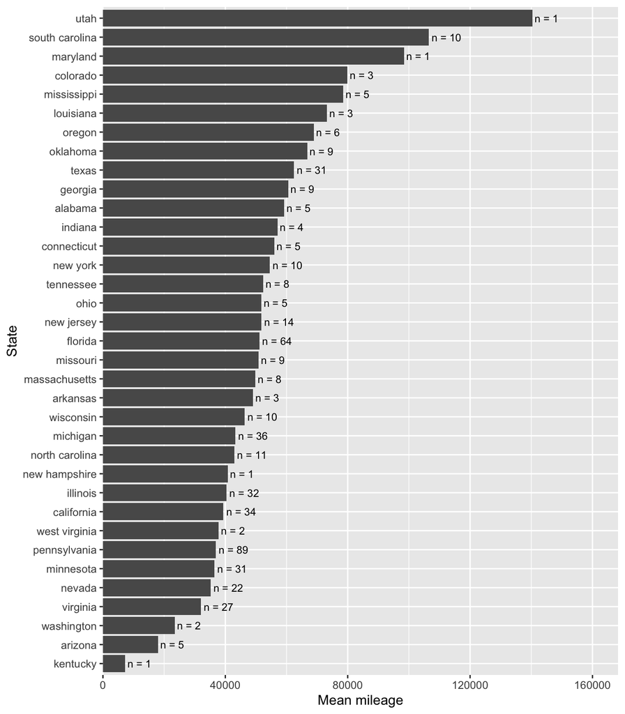

Mean mileage of black cars by state. Labels show the number of cars in each group.

```r
ggplot(
  black_cars_state_mileage,
  aes(x = mean_mileage, y = reorder(state, mean_mileage))
) +
  geom_col() +
  geom_text(aes(label = paste0("n = ", number_of_cars)), hjust = -0.1, size = 3) +
  scale_x_continuous(expand = expansion(mult = c(0, 0.2))) +
  labs(x = "Mean mileage", y = "State")
```

**Python**

`barh()` displays the states in the table’s row order, with the first state at the bottom.

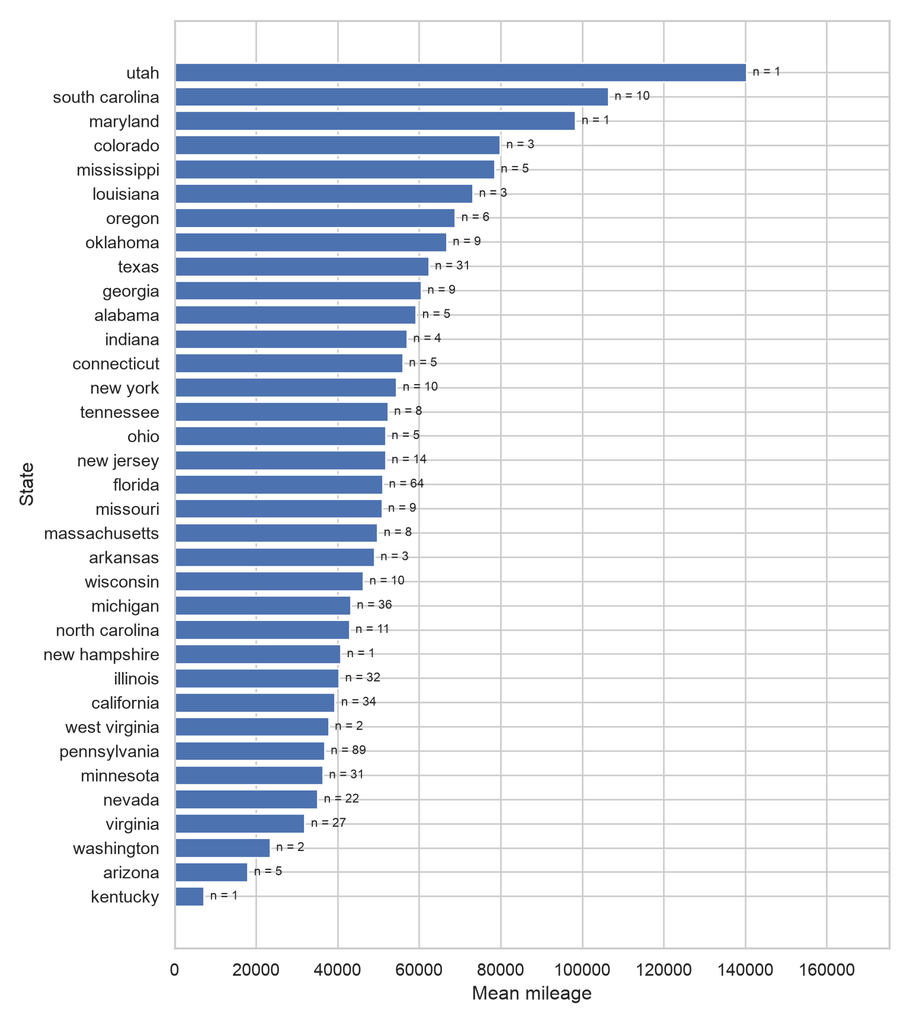

Mean mileage of black cars by state. Labels show the number of cars in each group.

```python
fig, ax = plt.subplots(figsize=(8, 9))
ax.barh(black_cars_state_mileage["state"], black_cars_state_mileage["mean_mileage"])
for row_number, row in enumerate(black_cars_state_mileage.itertuples()):
    ax.text(
        row.mean_mileage + 1500, row_number, f"n = {row.number_of_cars}",
        va="center", fontsize=8,
    )
ax.set(
    xlabel="Mean mileage", ylabel="State",
    xlim=(0, black_cars_state_mileage["mean_mileage"].max() * 1.25),
)
fig.tight_layout()
plt.show()
```

Which states have only one car? How much confidence would you have in comparing those states with states that have many observations?

### Other ways to pass data to a function

**R**

R also has the native pipe `|>`, available since R 4.1. It can be used for these data operations if you prefer it. For example:

```r
us_cars |>
  filter(color == "black")
```

```
# A tibble: 516 × 12
   price brand model  year title_status mileage color vin      lot state country
   <dbl> <chr> <chr> <dbl> <chr>          <dbl> <chr> <chr>  <dbl> <chr> <chr>
 1  6300 toyo… crui…  2008 clean vehic…  274117 black jtez… 1.59e8 new … usa
 2  7300 chev… pk     2010 clean vehic…  149050 black 1gcs… 1.68e8 geor… usa
 3  5250 ford  mpv    2017 clean vehic…   63418 black 2fmp… 1.68e8 texas usa
 4 31900 chev… 1500   2018 clean vehic…   22909 black 3gcu… 1.68e8 tenn… usa
 5 20700 ford  door   2013 clean vehic…  100757 black 1ftf… 1.68e8 virg… usa
 6  7300 kia   forte  2018 clean vehic…   38823 black 3kpf… 1.68e8 nort… usa
 7 15000 chev… door   2015 clean vehic…   61578 black 2gnf… 1.68e8 ohio  usa
 8 11900 gmc   door   2017 clean vehic…   27965 black 1gks… 1.68e8 cali… usa
 9 55000 ford  srw    2017 clean vehic…   15273 black 1ft7… 1.68e8 penn… usa
10 12520 gmc   door   2017 clean vehic…   28972 black 1gks… 1.68e8 cali… usa
# ℹ 506 more rows
# ℹ 1 more variable: condition <chr>
```

`%>%` is supplied by tidyverse/dplyr, while `|>` is part of base R.

**Python**

pandas `.pipe(function, ...)` passes the current table as the first argument of a function. This is useful for custom functions. Python has no `|>` operator.

```python
def select_black_cars(data):
    return data.loc[data["color"] == "black"]

us_cars.pipe(select_black_cars).head()
```

```
    price      brand    model  ...       state country      condition
0    6300     toyota  cruiser  ...  new jersey     usa   10 days left
6    7300  chevrolet       pk  ...     georgia     usa  22 hours left
9    5250       ford      mpv  ...       texas     usa    2 days left
12  31900  chevrolet     1500  ...   tennessee     usa  22 hours left
14  20700       ford     door  ...    virginia     usa  22 hours left

[5 rows x 12 columns]
```

## Pivoting

The `table2` example records tuberculosis cases and population in different rows for a few countries in 1999 and 2000. Take a look at the table. Why is it not tidy?

**R**

```r
table2 <- read_csv(file.path("data", "table2.csv"))
table2
```

```
# A tibble: 12 × 4
   country      year type            count
   <chr>       <dbl> <chr>           <dbl>
 1 Afghanistan  1999 cases             745
 2 Afghanistan  1999 population   19987071
 3 Afghanistan  2000 cases            2666
 4 Afghanistan  2000 population   20595360
 5 Brazil       1999 cases           37737
 6 Brazil       1999 population  172006362
 7 Brazil       2000 cases           80488
 8 Brazil       2000 population  174504898
 9 China        1999 cases          212258
10 China        1999 population 1272915272
11 China        2000 cases          213766
12 China        2000 population 1280428583
```

**Python**

```python
table2 = pd.read_csv(DATA_DIR / "table2.csv")
table2
```

```
        country  year        type       count
0   Afghanistan  1999       cases         745
1   Afghanistan  1999  population    19987071
2   Afghanistan  2000       cases        2666
3   Afghanistan  2000  population    20595360
4        Brazil  1999       cases       37737
5        Brazil  1999  population   172006362
6        Brazil  2000       cases       80488
7        Brazil  2000  population   174504898
8         China  1999       cases      212258
9         China  1999  population  1272915272
10        China  2000       cases      213766
11        China  2000  population  1280428583
```

The problem is that `cases` and `population` are different variables but do not have their own columns. We can pivot the table into a wider form.

**R**

`names_from` gives the column storing variable names; `values_from` gives the column storing their values.

```r
table2_tidy <- pivot_wider(
  table2,
  names_from = "type",
  values_from = "count"
)
table2_tidy
```

```
# A tibble: 6 × 4
  country      year  cases population
  <chr>       <dbl>  <dbl>      <dbl>
1 Afghanistan  1999    745   19987071
2 Afghanistan  2000   2666   20595360
3 Brazil       1999  37737  172006362
4 Brazil       2000  80488  174504898
5 China        1999 212258 1272915272
6 China        2000 213766 1280428583
```

**Python**

`columns` gives the column storing variable names; `values` gives the column storing their values. `index` identifies each country-year observation. `.reset_index()` makes these identifiers ordinary columns again.

```python
table2_tidy = table2.pivot(index=["country", "year"], columns="type", values="count").reset_index()
table2_tidy.columns.name = None
table2_tidy
```

```
       country  year   cases  population
0  Afghanistan  1999     745    19987071
1  Afghanistan  2000    2666    20595360
2       Brazil  1999   37737   172006362
3       Brazil  2000   80488   174504898
4        China  1999  212258  1272915272
5        China  2000  213766  1280428583
```

These examples assume each country-year-type combination occurs once. If combinations repeat, decide how to handle them before pivoting. In pandas, `.pivot_table()` can aggregate repeated combinations.

Now it’s easy to visualize the number of cases.

**R**

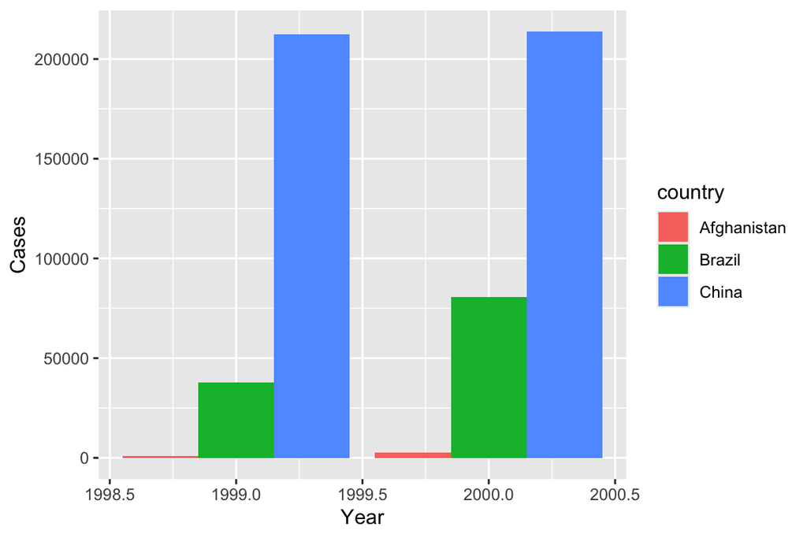

Tuberculosis cases in Afghanistan, Brazil, and China in 1999 and 2000.

```r
ggplot(table2_tidy, aes(year, cases, fill = country)) +
  geom_col(position = "dodge") +
  labs(x = "Year", y = "Cases")
```

**Python**

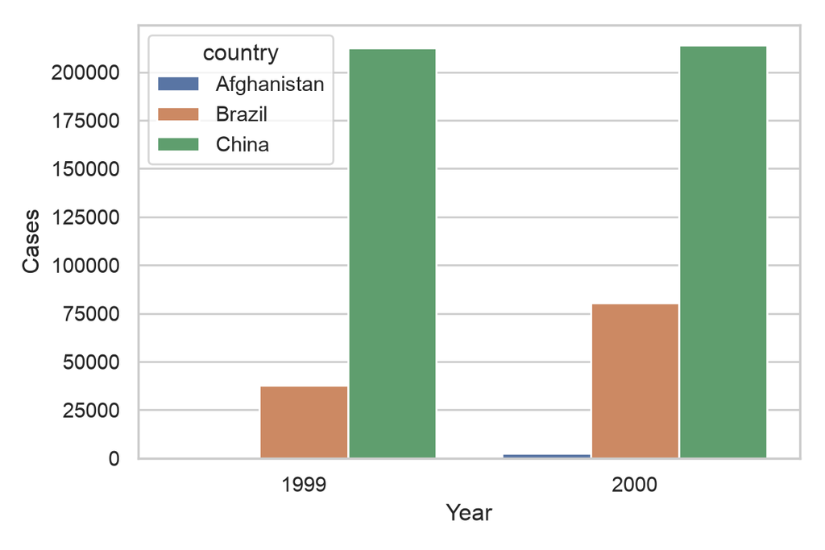

Tuberculosis cases in Afghanistan, Brazil, and China in 1999 and 2000.

```python
fig, ax = plt.subplots(figsize=(6, 4))
sns.barplot(data=table2_tidy, x="year", y="cases", hue="country", ax=ax, errorbar=None)
ax.set(xlabel="Year", ylabel="Cases")
fig.tight_layout()
plt.show()
```

To move the variables back into rows, use `pivot_longer()` in R or `.melt()` in pandas. The row order can differ from the original, even when the information is the same. A round trip cannot recover information lost through aggregation.

**R**

```r
table2_messy <- pivot_longer(
  table2_tidy,
  cols = c("cases", "population"),
  names_to = "type",
  values_to = "count"
)
table2_messy
```

```
# A tibble: 12 × 4
   country      year type            count
   <chr>       <dbl> <chr>           <dbl>
 1 Afghanistan  1999 cases             745
 2 Afghanistan  1999 population   19987071
 3 Afghanistan  2000 cases            2666
 4 Afghanistan  2000 population   20595360
 5 Brazil       1999 cases           37737
 6 Brazil       1999 population  172006362
 7 Brazil       2000 cases           80488
 8 Brazil       2000 population  174504898
 9 China        1999 cases          212258
10 China        1999 population 1272915272
11 China        2000 cases          213766
12 China        2000 population 1280428583
```

**Python**

```python
table2_messy = table2_tidy.melt(
    id_vars=["country", "year"], value_vars=["cases", "population"],
    var_name="type", value_name="count",
)
table2_messy
```

```
        country  year        type       count
0   Afghanistan  1999       cases         745
1   Afghanistan  2000       cases        2666
2        Brazil  1999       cases       37737
3        Brazil  2000       cases       80488
4         China  1999       cases      212258
5         China  2000       cases      213766
6   Afghanistan  1999  population    19987071
7   Afghanistan  2000  population    20595360
8        Brazil  1999  population   172006362
9        Brazil  2000  population   174504898
10        China  1999  population  1272915272
11        China  2000  population  1280428583
```

**Try it:** summarize the price of red cars by brand. Include the group sizes, sort the results, and decide how you would display them.

Download the Quarto source.